# HW2

2024-04-22

Q0

Q0 C:

```r
# Specify a CRAN mirror for package installation
cran_mirror <- "https://cran.rstudio.com/"

# Install necessary packages
packages <- c("bookdown", "tidyverse", "ggplot2", "devtools", "roxygen2", "usethis")
for (pkg in packages) {
  if (!require(pkg, character.only = TRUE, quietly = TRUE)) {
    install.packages(pkg, repos = cran_mirror)
    library(pkg, character.only = TRUE)
  }
}
# Set the path for the new package
path_to_package <- "/Users/wangruyue/Desktop/UWBiost561"

# Check if the directory is appropriately prepared for a new package
if (length(list.files(path_to_package)) == 0) {
  # Create the package without trying to open it in RStudio
  usethis::create_package(path = path_to_package, open = FALSE)

  # Set working directory to the new package
  setwd(path_to_package)

  # Add and use roxygen2 for documentation
  usethis::use_roxygen_md()

  # Assuming here you will add functions and documentation as needed...

  # Document the package
  roxygen2::roxygenise()

  # Install the package locally
  devtools::install()

  # Load the package
  library(UWBiost561)
} else {
  message("Directory is not empty. Ensure it's the right path or clear it before creating the package.")
}
```

```
## Directory is not empty. Ensure it's the right path or clear it before creating the package.
```

Q0 D:

```r
setwd("/Users/wangruyue/Desktop/UWBiost561/vignettes")  # Adjust path as needed
# List files in the current directory
files <- list.files()
print(files)
```

```
## [1] "HW1.html" "HW1.Rmd"
```

```r
# Define the expected files
expected_files <- c("HW1.html", "HW1.Rmd", "HW2.Rmd", "HW2.html")

# Check for unexpected files
unexpected_files <- setdiff(files, expected_files)
if (length(unexpected_files) > 0) {
  cat("Unexpected files found:", unexpected_files, "\n")
}

# Check if any expected files are missing
missing_files <- setdiff(expected_files, files)
if (length(missing_files) > 0) {
  cat("Missing files:", missing_files, "\n")
}
```

```
## Missing files: HW2.Rmd HW2.html
```

```r
# Check for .gitignore and delete it
if (".gitignore" %in% files) {
  file.remove(".gitignore")
  cat(".gitignore file found and deleted.\n")
} else {
  cat("No .gitignore file present.\n")
}
```

```
## No .gitignore file present.
```

```r
# List files again to confirm the current state
final_files <- list.files()
print(final_files)
```

```
## [1] "HW1.html" "HW1.Rmd"
```

Q1

Q1 A:

```r
library(tidyverse)

country_population <- readr::read_csv("https://raw.githubusercontent.com/linnykos/561_s2024_public/main/HW2_files/country_population.csv")
# Filter the data for years 1990 to 2010 and calculate the mean population for each country
country_population_summary <- country_population %>%
  filter(year >= 1990, year <= 2010) %>%
  group_by(iso3c, country) %>%
  summarize(mean_population = mean(population, na.rm = TRUE)) %>%
  ungroup()
print(country_population_summary)
```

```
## # A tibble: 215 × 3
##    iso3c country              mean_population
##    <chr> <chr>                          <dbl>
##  1 ABW   Aruba                         85839.
##  2 AFG   Afghanistan                19819866.
##  3 AGO   Angola                     16829911.
##  4 ALB   Albania                     3095489.
##  5 AND   Andorra                       67825.
##  6 ARE   United Arab Emirates        3858774.
##  7 ARG   Argentina                  36972314.
##  8 ARM   Armenia                     3211816.
##  9 ASM   American Samoa                54995.
## 10 ATG   Antigua and Barbuda           74385.
## # ℹ 205 more rows
```

Q1 B:

```r
country_birth <- readr::read_csv("https://raw.githubusercontent.com/linnykos/561_s2024_public/main/HW2_files/country_birth.csv")
country_birth
```

```
## # A tibble: 5,486 × 5
##    iso3c  year life_expect birth_rate neonat_mortal_rate
##    <chr> <dbl>       <dbl>      <dbl>              <dbl>
##  1 AND    1994          NA       10.9                3.2
##  2 AND    1995          NA       11                  3
##  3 AND    2006          NA       10.6                1.9
##  4 AND    2007          NA       10.1                1.8
##  5 AND    1996          NA       10.9                2.8
##  6 AND    1993          NA       11.4                3.4
##  7 AND    1997          NA       11.2                2.6
##  8 AND    1998          NA       11.9                2.4
##  9 AND    2008          NA       10.4                1.8
## 10 AND    2009          NA        9.9                1.7
## # ℹ 5,476 more rows
```

```r
library(tidyverse)

country_birth_summary <- country_birth %>%
  filter(year >= 1990 & year <= 2010) %>%                # Select years between 1990 and 2010
  select(iso3c, year, life_expect) %>%                   # Keep only specified columns
  drop_na() %>%                                          # Drop rows with any NA values
  group_by(iso3c) %>%                                    # Group by country code
  summarize(
    min_life_expect = min(life_expect),                  # Calculate minimum life expectancy
    max_life_expect = max(life_expect)                   # Calculate maximum life expectancy
  ) %>%
  mutate(range_life_expect = max_life_expect - min_life_expect)  # Calculate range of life expectancy

country_birth_summary
```

```
## # A tibble: 203 × 4
##    iso3c min_life_expect max_life_expect range_life_expect
##    <chr>           <dbl>           <dbl>             <dbl>
##  1 ABW              73.4            75.0              1.56
##  2 AFG              49.9            59.0              9.11
##  3 AGO              41.1            50.7              9.52
##  4 ALB              71.9            77.0              5.14
##  5 ARE              71.7            76.7              4.96
##  6 ARG              71.5            75.5              3.94
##  7 ARM              67.7            74.2              6.49
##  8 ATG              71.2            75.3              4.15
##  9 AUS              77.0            81.7              4.70
## 10 AUT              75.6            80.6              5.01
## # ℹ 193 more rows
```

Q1 C:

```r
library(tidyverse)

# Assuming 'country_population' and 'country_birth' have been previously created and are in your workspace

# Join the datasets
country_both <- inner_join(country_population, country_birth, by = "iso3c")
# Print out the first 10 rows
print(slice(country_both, 1:10))
```

```
## # A tibble: 10 × 8
##    iso3c country year.x population year.y life_expect birth_rate
##    <chr> <chr>    <dbl>      <dbl>  <dbl>       <dbl>      <dbl>
##  1 ABW   Aruba     1960      54608   1990        73.4       19.6
##  2 ABW   Aruba     1960      54608   1992        73.5       18.4
##  3 ABW   Aruba     1960      54608   1994        73.5       17.3
##  4 ABW   Aruba     1960      54608   2006        74.4       12.0
##  5 ABW   Aruba     1960      54608   2003        74.0       13.0
##  6 ABW   Aruba     1960      54608   1993        73.5       17.9
##  7 ABW   Aruba     1960      54608   2005        74.2       12.3
##  8 ABW   Aruba     1960      54608   2007        74.5       11.7
##  9 ABW   Aruba     1960      54608   1996        73.6       16.1
## 10 ABW   Aruba     1960      54608   2004        74.1       12.7
## # ℹ 1 more variable: neonat_mortal_rate <dbl>
```

```r
# Get the dimensions of the combined dataset
dim(country_both)
```

```
## [1] 343980      8
```

The country_both has 343980 rows and 8 columns.

Q2

Q2 A:

```r
penguins <- readr::read_csv("https://raw.githubusercontent.com/linnykos/561_s2024_public/main/HW2_files/palmerpenguins.csv")
penguins
```

```
## # A tibble: 333 × 8
##    species island    bill_length_mm bill_depth_mm flipper_length_mm body_mass_g
##    <chr>   <chr>              <dbl>         <dbl>             <dbl>       <dbl>
##  1 Adelie  Torgersen           39.1          18.7               181        3750
##  2 Adelie  Torgersen           39.5          17.4               186        3800
##  3 Adelie  Torgersen           40.3          18                 195        3250
##  4 Adelie  Torgersen           36.7          19.3               193        3450
##  5 Adelie  Torgersen           39.3          20.6               190        3650
##  6 Adelie  Torgersen           38.9          17.8               181        3625
##  7 Adelie  Torgersen           39.2          19.6               195        4675
##  8 Adelie  Torgersen           41.1          17.6               182        3200
##  9 Adelie  Torgersen           38.6          21.2               191        3800
## 10 Adelie  Torgersen           34.6          21.1               198        4400
## # ℹ 323 more rows
## # ℹ 2 more variables: sex <chr>, year <dbl>
```

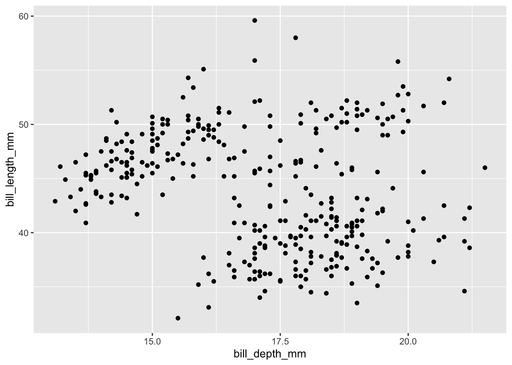

```r
penguins %>%
  ggplot(aes(x = bill_depth_mm, y = bill_length_mm)) +
  geom_point()
```

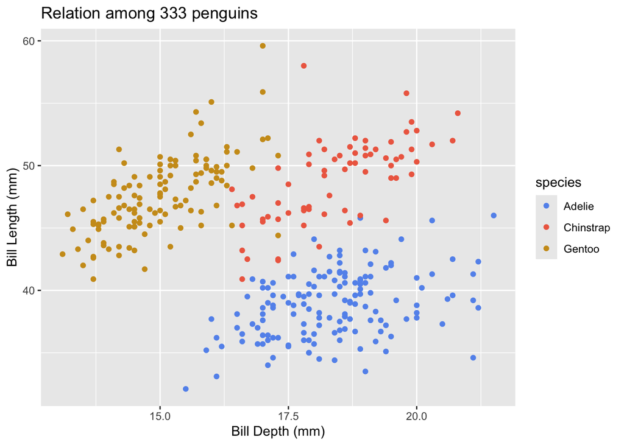

```r
# Count the number of rows (penguins) in the dataset
num_penguins <- nrow(penguins)

# Create the scatter plot
penguins_plot <- penguins %>%
  ggplot(aes(x = bill_depth_mm, y = bill_length_mm, color = species)) +
  geom_point() +
  scale_color_manual(values = c("Adelie" = "cornflowerblue", "Chinstrap" = "coral2", "Gentoo" = "goldenrod3")) +
  labs(
    title = paste("Relation among", num_penguins, "penguins"),
    x = "Bill Depth (mm)",
    y = "Bill Length (mm)",
    color = "species"
  )

# Print the plot
print(penguins_plot)
```

```r
library(tidyverse)

# Load the penguins dataset
penguins <- readr::read_csv("https://raw.githubusercontent.com/linnykos/561_s2024_public/main/HW2_files/palmerpenguins.csv")
```

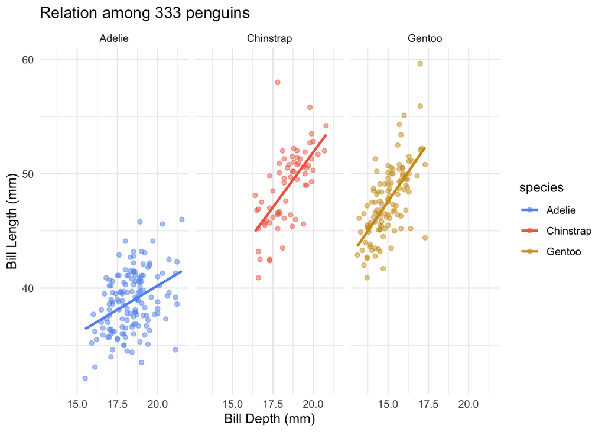

```r
# Create the scatter plot with the additional modifications
penguins_plot <- penguins %>%
  ggplot(aes(x = bill_depth_mm, y = bill_length_mm, color = species)) +
  geom_point(alpha = 0.5) +  # Set transparency to 50%
  geom_smooth(method = "lm", se = FALSE) +  # Add linear regression fit without standard error band
  facet_wrap(~species) +  # Facet the plot by species
  scale_color_manual(values = c("Adelie" = "cornflowerblue", "Chinstrap" = "coral2", "Gentoo" = "goldenrod3")) +
  labs(
    title = paste("Relation among", nrow(penguins), "penguins"),
    x = "Bill Depth (mm)",
    y = "Bill Length (mm)",
    color = "species"
  ) +
  theme_minimal()  # Optional: Adds a minimal theme

# Print the plot
print(penguins_plot)
```

Q3

Q3 A:

The function takes three arguments: the number of nodes n, the fraction of these nodes that will form a clique clique_fraction, and the density of edges in the non-clique part of the graph density_low. The result is an adjacency matrix (adj_mat), where each cell contains either a 1 (if an edge is present) or a 0 (if no edge is present), describing the connections between each pair of nodes in the graph. The function returns a list containing the adjacency matrix and a vector indicating which nodes are part of the clique.

Q3 B:

The pivot_longer_heatmap() function is designed to reshape a matrix into a “long” data frame format suitable for plotting with ggplot2. Specifically for heatmaps, data must be in a three-column format, where each row represents a single tile of the heatmap. It assigns row and column names if they are not already assigned. It uses the melt() function from the reshape2 package (or a similar operation with tidyr::pivot_longer()) to transform the adjacency matrix into a long data frame. This process involves “melting” the matrix, so each element of the matrix becomes a row in the data frame. The resulting data frame has three columns: ‘X’ for the row number, ‘Y’ for the column number, and ‘Value’ for the elements of the matrix (1s and 0s from the adjacency matrix). In this long format, each row corresponds to the position of a node connection (X, Y) and the value (presence or absence of an edge) in the adjacency matrix. This long format is necessary for ggplot2 to plot each value of the adjacency matrix as a square or “tile” on the heatmap, where ‘X’ and ‘Y’ determine the position of the tile, and ‘Value’ determines its fill color.

If adj_mat[1,1] is 1, adj_mat[1,2] is 0, and adj_mat[1,3] is 1, then in mat_long, you would see the first three rows as: X = 1, Y = 1, Value = 1 X = 1, Y = 2, Value = 0 X = 1, Y = 3, Value = 1

Q3 C:

```r
library(ggplot2)
source("https://raw.githubusercontent.com/linnykos/561_s2024_public/main/HW2_files/random_graph_functions.R")
set.seed(0)
result <- generate_random_graph(n = 20,
                                clique_fraction = 0.5,
                                density_low = 0.1)
adj_mat <- result$adj_mat
dim(adj_mat)
```

```
## [1] 20 20
```

```r
adj_mat[1:5,1:5]
```

```
##      [,1] [,2] [,3] [,4] [,5]
## [1,]    1    0    1    0    0
## [2,]    0    1    1    1    1
## [3,]    1    1    1    0    0
## [4,]    0    1    0    1    0
## [5,]    0    1    0    0    1
```

```r
mat_long <- pivot_longer_heatmap(adj_mat)
mat_long
```

```
## # A tibble: 400 × 3
##        X     Y Value
##    <int> <dbl> <dbl>
##  1     1     1     1
##  2     1     2     0
##  3     1     3     1
##  4     1     4     0
##  5     1     5     0
##  6     1     6     1
##  7     1     7     0
##  8     1     8     0
##  9     1     9     0
## 10     1    10     0
## # ℹ 390 more rows
```

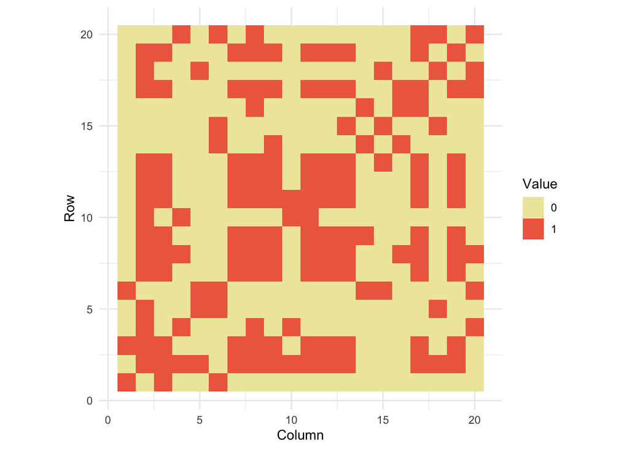

```r
# Plot the heatmap
heatmap_plot <- ggplot(mat_long, aes(x = X, y = Y, fill = factor(Value))) +
  geom_tile() +
  scale_fill_manual(values = c("0" = "palegoldenrod", "1" = "coral2")) +
  coord_fixed(ratio = 1) +
  labs(fill = "Value", x = "Column", y = "Row") +
  theme_minimal()  # For a minimalistic design

# Print the heatmap plot
print(heatmap_plot)
```

Q3 D:

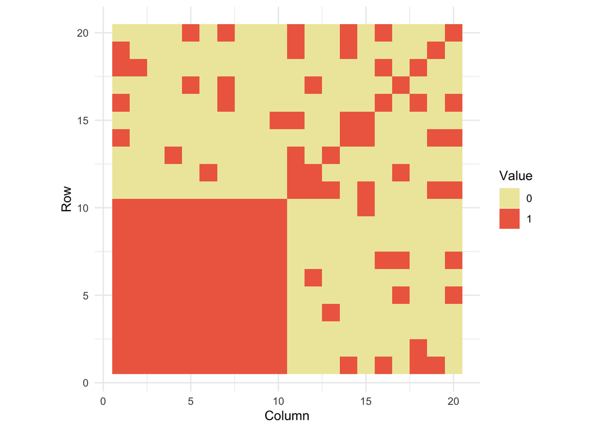

```r
library(tidyverse)
source("https://raw.githubusercontent.com/linnykos/561_s2024_public/main/HW2_files/random_graph_functions.R")

# Set seed for reproducibility
set.seed(0)

# Generate the random graph adjacency matrix
result <- generate_random_graph(n = 20, clique_fraction = 0.5, density_low = 0.1)

# Permute the rows and columns of the adjacency matrix
adj_mat2 <- result$adj_mat[result$rev_order, result$rev_order]

# Convert adj_mat2 to long format for ggplot
mat_long2 <- pivot_longer_heatmap(adj_mat2)

# Plot the heatmap
heatmap_plot2 <- ggplot(mat_long2, aes(x = X, y = Y, fill = factor(Value))) +
  geom_tile() +
  scale_fill_manual(values = c("0" = "palegoldenrod", "1" = "coral2")) +
  coord_fixed(ratio = 1) +
  labs(fill = "Value", x = "Column", y = "Row") +
  theme_minimal()

# Print the heatmap plot
print(heatmap_plot2)
```

Q4

1. Test against adjacency matrices where the maximal cliques are known. This includes simple cases with a single clique or no cliques, and more complex graphs where the cliques are documented, perhaps from a curated dataset in graph theory literature.
2. Generate large random graphs with varying densities and structures, including some with planted cliques of known sizes. This helps in checking if the function can handle high-complexity inputs and if it scales well with the size of the graph.
3. Use the function in conjunction with other clique-finding algorithms or software, where possible, to cross-verify results. Discrepancies can help identify specific situations where the function may fail.
4. Consider edge cases such as an empty graph, a complete graph (every node is connected to every other node), and graphs with isolated nodes (no connections). Ensuring the function behaves as expected in these situations is critical for validating its general correctness.